# La borrasca Filomena

Authors

Gema Fernández-Avilés

Isidro Higalgo

Published

December 17, 2024

**Note**

Los datos que se utilizan en esta historia están disponibles en el paquete `CDR` que puede instalarse con el siguiente comando:

```r
install.packages("remotes")
remotes::install_github("cdr-book/CDR")
```

Los datos referentes a la temperatura en España han sido recopilados por la Agencia Estatal de Meteorología (AEMET) y descargados en **R* con el paquete climatológico `climaemet` y los mapas de España han sido procesados con el paquete `mapSpain`.

# 1 Preparar los datos

Lectura de datos:

```r
library(CDR)        # Para los datos de temperatura
head(tempmin_data)
```

```
       fecha indicativo tmin  longitud  latitud
1 2021-01-06      4358X -4.7 -5.880556 38.95556
2 2021-01-06      4220X -7.0 -4.616389 39.08861
3 2021-01-06      6106X  4.7 -4.748333 37.02944
4 2021-01-06      9698U -6.8  0.865278 42.20528
5 2021-01-06      4410X -3.4 -6.385556 38.91583
6 2021-01-06      1331A  1.0 -7.031389 43.52472
```

```r
library(mapSpain)  # Para mapas de España. Filta las Islas Canarias
library(dplyr)     # Para manipulación de datos
esp <- esp_get_ccaa() |>
  filter(ine.ccaa.name != "Canarias")
```

# 2 Limpiar y preparar los datos

Verificamos que los sistemas de coordenadas sean los mismos y transformamos si es necesario.

```r
library(sf)
tmin_sf <- st_as_sf(tempmin_data, coords = c("longitud", "latitud"), crs = 4326)
```

```r
# Verificar y transformar CRS
if (st_crs(tmin_sf) != st_crs(esp)) {
  esp <- st_transform(esp, st_crs(tmin_sf))
}
```

# 3 Crear visualizaciones iniciales

Generamos un boxplot de las temperaturas mínimas.

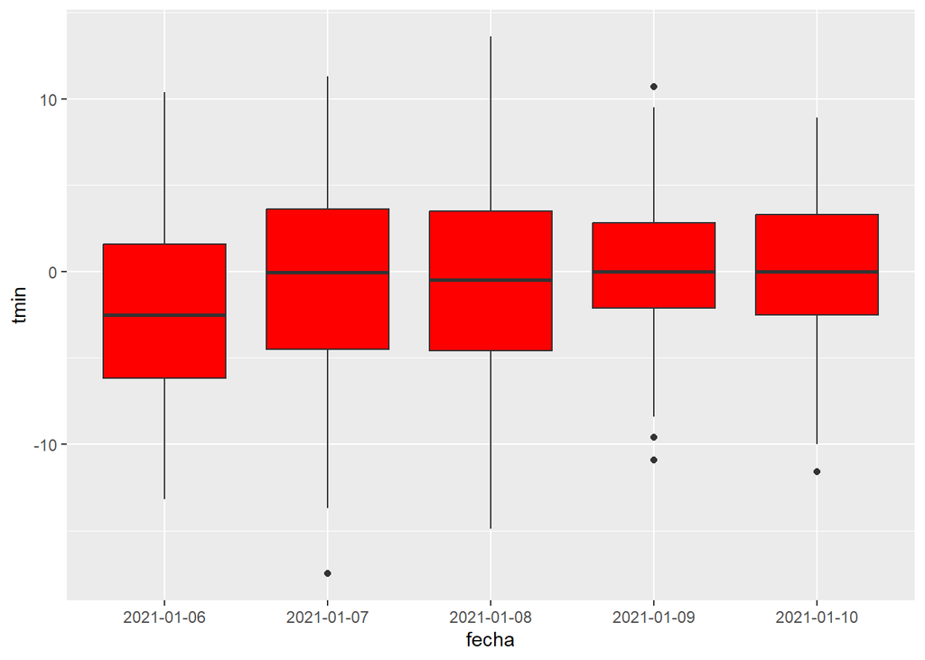

```r
library(ggplot2)
ggplot(tempmin_data, aes(x = fecha, y = tmin)) +
  geom_boxplot(fill = "red")
```

# 4 Contar la historia con los datos

Aplicamos los principios de storytelling para mejorar la visualización.

## 4.1 Contexto

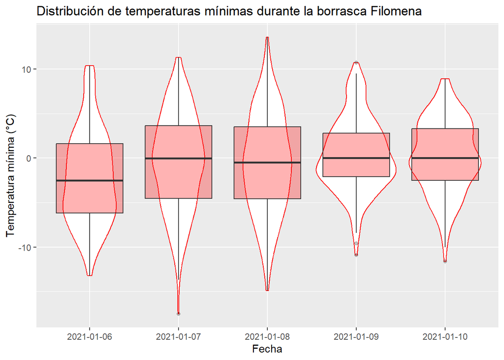

```r
boxplot_inicial <- ggplot(tempmin_data, aes(x = fecha, y = tmin)) +
  geom_violin(color = "red") +
  geom_boxplot(alpha = 0.3, fill = "red") +
  labs(title = "Distribución de temperaturas mínimas durante la borrasca Filomena",
       x = "Fecha", y = "Temperatura mínima (°C)")

boxplot_inicial
```

## 4.2 Simplificación

Eliminamos elementos innecesarios del gráfico para que el enfoque esté en los datos clave.

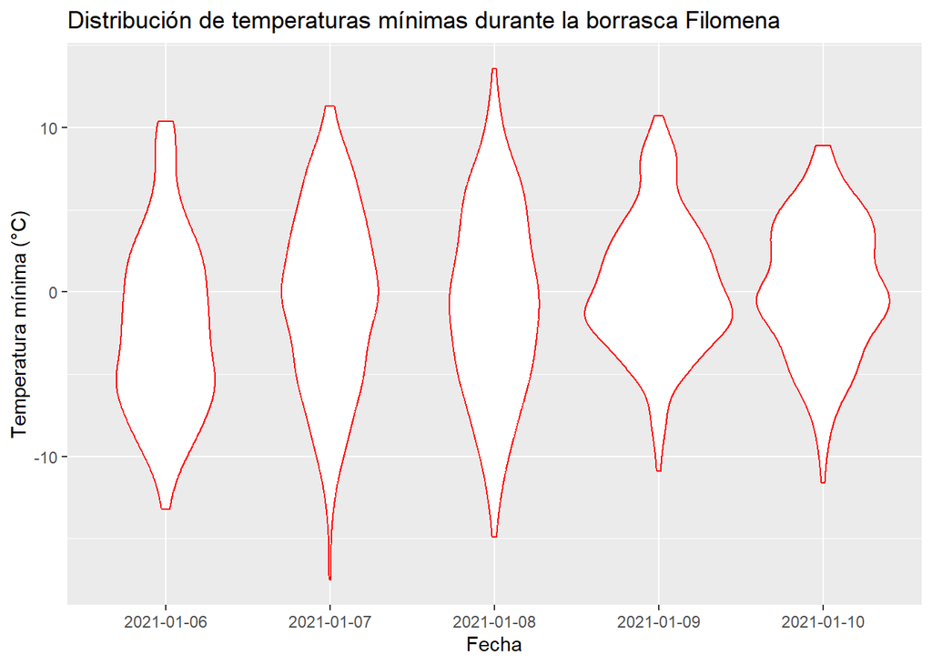

```r
ggplot(tempmin_data, aes(x = fecha, y = tmin)) +
  geom_violin(color = "red") +
  labs(title = "Distribución de temperaturas mínimas durante la borrasca Filomena",
       x = "Fecha", y = "Temperatura mínima (°C)")
```

## 4.3 Destacar

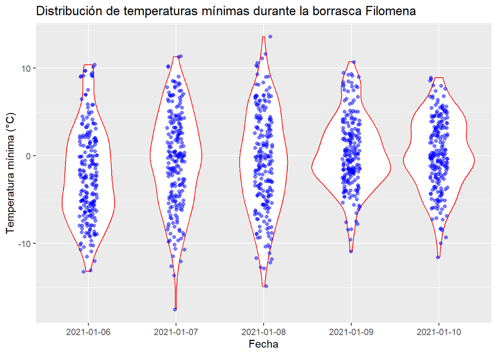

```r
ggplot(tempmin_data, aes(x = fecha, y = tmin)) +
  geom_violin(color = "red") +
  geom_jitter(width = 0.1, alpha = 0.5, col = "blue") +
  labs(title = "Distribución de temperaturas mínimas durante la borrasca Filomena",
       x = "Fecha", y = "Temperatura mínima (°C)")
```

## 4.4 Diseño

Aseguramos que el diseño sea limpio y fácil de entender, utilizando un tema claro y legible.

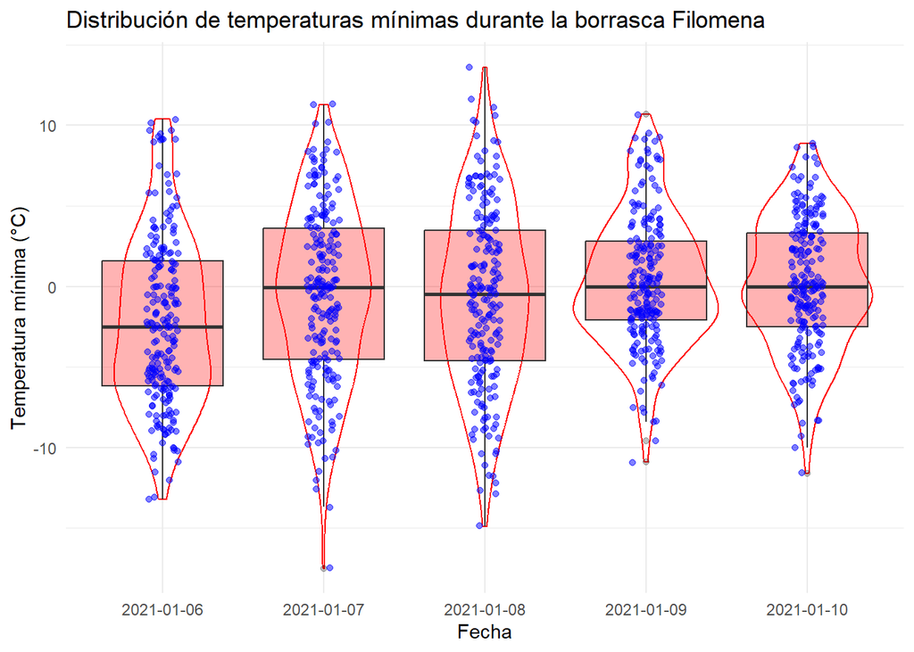

```r
boxplot_final<- ggplot(tempmin_data, aes(x = fecha, y = tmin)) +
  geom_violin(color = "red") +
  geom_boxplot(alpha = 0.3, fill = "red") +
  geom_jitter(width = 0.1, alpha = 0.5, col = "blue") +
  theme_minimal() +
  labs(title = "Distribución de temperaturas mínimas durante la borrasca Filomena",
       x = "Fecha", y = "Temperatura mínima (°C)")

boxplot_final
```

# 5 Tu turno

Seleccionamos un día de los afectados por la borrasca Filomena, el 6 de enero, y visualizamos las temperaturas mínimas en un mapa para ver las zonas más afectadas.

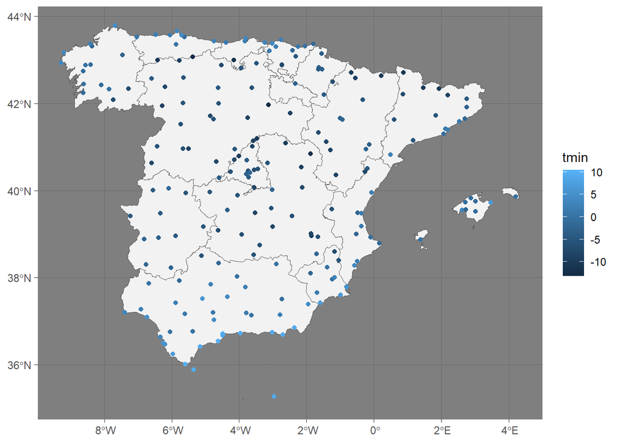

```r
tmin_6enero <- tmin_sf |>
  filter(fecha == "2021-01-06")

mapa_inicial <- ggplot() +
  geom_sf(data = esp, fill = "grey95") +
  geom_sf(data = tmin_6enero, aes(color = tmin)) +
  theme_dark()

mapa_inicial
```

Aplica los principios de storytelling para mejorar la visualización:

1. **Contexto**
2. **Simplificación**
3. **Destacar**
4. **Diseño**

**Objetivo**

Completa las partes del código señaladas por `______` o `xxx` para obtener el resultado propuesto.

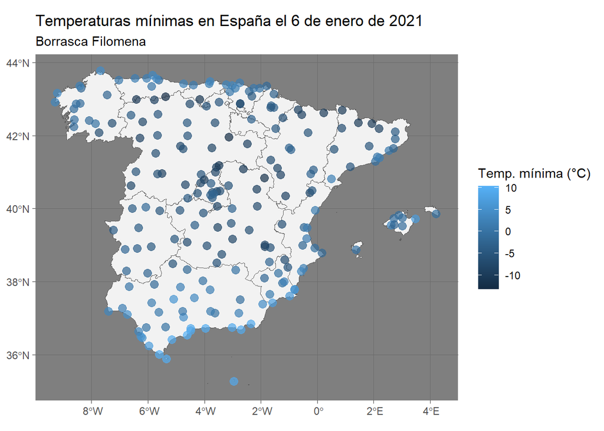

**Objetivo 1**

[figure not shown]

```r
ggplot() +
  geom_sf(data = esp, fill = "grey95") +
  geom_sf(data = _________, aes(color = tmin), size = 3, alpha = 0.7) +
  theme_dark() +
  labs(title = "__________",
       _______ = "Borrasca Filomena",
       color = "Temp. mínima (°C)")
```

**Objetivo 2**

```r
ggplot() +
  geom_xxxf(data = esp, fill = "grey95") +
  geom_xxx(data = tmin_6enero, aes(color = tmin), size = 3, alpha = 0.7) +
  scale_color_viridis_c() +
  theme_xxx() +
  labs(title = "Temperaturas mínimas en España el 6 de enero de 2021",
       subtitle = "Durante la Borrasca Filomena",
       color = "Temp. mínima (°C)")
```

¿Por qué no un gráfico espacio-temporal?

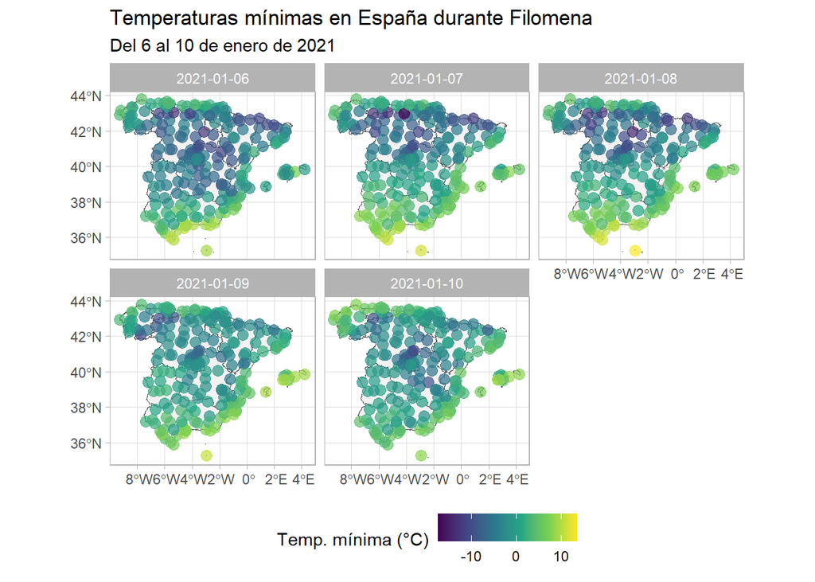

**Objetivo 3**

```r
ggplot() +
  geom_sf(data = esp, fill = "grey95") +
  geom_sf(data = tmin_sf, aes(color = tmin), size = 3, alpha = 0.7) +
  facet_xxx(vars(fecha), ncol = 3) +
  scale_color_xxxxxx() +
  theme_light() +
  labs(title = "Temperaturas mínimas en España durante Filomena",
       subtitle = "Del 6 al 10 de enero de 2021",
       color = "Temp. mínima (°C)") +
  theme(legend.position = "_______")
```

**Objetivo 4**

Realizamos ajustes finales para mejorar la claridad y el impacto visual.

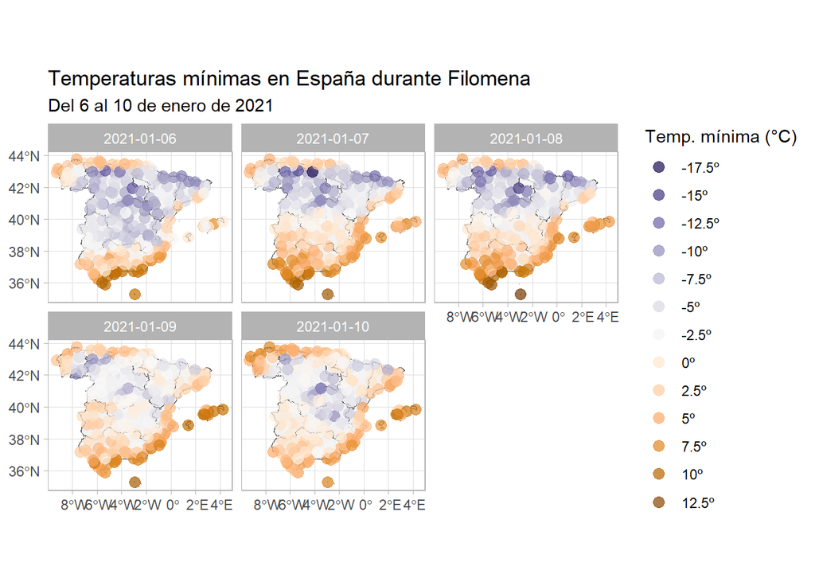

```r
# echo: false
cortes <- c(-Inf, seq(-20, 20, 2.5), Inf)
colores <- hcl.colors(15, "PuOr", rev = TRUE)

ggplot() +
  geom_sf(data = esp, fill = "grey95") +
  geom_sf(data = tmin_sf, aes(color = tmin), size = 3, alpha = 0.7) +
  facet_wrap(vars(fecha), ncol = 3) +
  scale_color_gradientn(colours = colores, breaks = cortes,
                        labels = ~ stringr::str_c(. , "º"),
                        guide = "legend") +
  theme_light() +
  labs(title = "Temperaturas mínimas en España durante Filomena",
       subtitle = "Del 6 al 10 de enero de 2021",
       color = "Temp. mínima (°C)")
```